# act_report

## Analyzing and Visualizing Data

### Here are observations and visual insights from the Data Analysis we performed on *WeRateDogs*

```python
# Import the necessary Libraries for the Project
import pandas as pd
import numpy as np
import matplotlib.pyplot as plt
import requests
from PIL import Image
from io import BytesIO
import seaborn as sns
%matplotlib inline
```

```python
df = pd.read_csv('twitter_archive_master.csv')
```

## 1 - Insight

### The Golden Retriever is the Top Dog Breed

*Takeaways*

*"The **Golden Retriever** is the top dog breed. You can see this breed of dog beat out other popular ones, such as the Labrador Retriever, Pembroke and the Chihuahua. Which are all great dogs! The total count for the Golden Retriever is substantially ahead of all the other breeds. This suggest that the **First Prediction** tally in the dataset are heavily weight towards this breed. With this high rate of dog breed, I would think people are willing to purchase a dog with such high standars, at any cost!"*

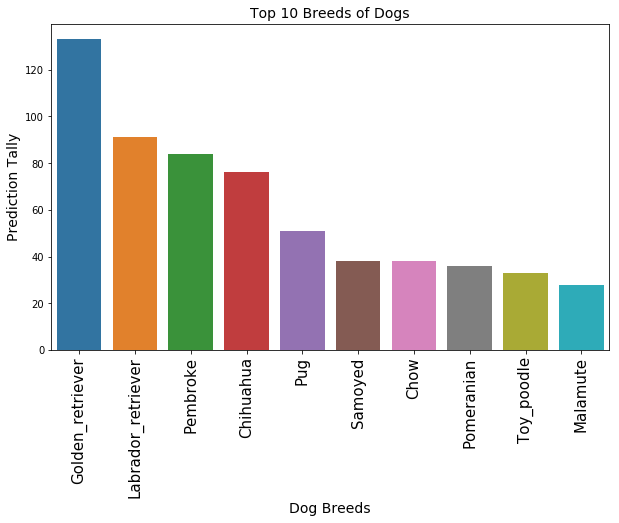

```python
# Plot the chart with the Top Dog Breeds
plt.figure(figsize = (10,6))
ax = sns.barplot(x = df['Prediction1'].value_counts()[0:10].index,
            y = df['Prediction1'].value_counts()[0:10],
            data = df);
ax.set_xticklabels(ax.get_xticklabels(),rotation = 90, fontsize = 15);
plt.xlabel("Dog Breeds",fontsize = 14);
plt.ylabel("Prediction Tally",fontsize = 14);
plt.title("Top 10 Breeds of Dogs",fontsize = 14);
```

## 2 - Insight

### The Top Dog Name goes to "Charlie"

*Takeaways*

*"Wow, can you believe **"Charlie"** is the most popular dog name. Oliver is there neck to neck in this category, with some of the other great names **(Lucy and Cooper)**. This name is so close to the adult names that we are commonly use to, such as Charles and Chuck. Which leads me to be believe, people truly treat their dogs as a biological children and part of "The Family". **Great Job Charlie!**"*

```python
# Charlie is the Top Dog name
freq_names = df.name.value_counts().nlargest(10)
freq_names
```

```
Charlie    11
Lucy       10
Cooper     10
Oliver     10
Tucker      9
Penny       9
Winston     8
Sadie       8
Lola        7
Daisy       7
Name: name, dtype: int64
```

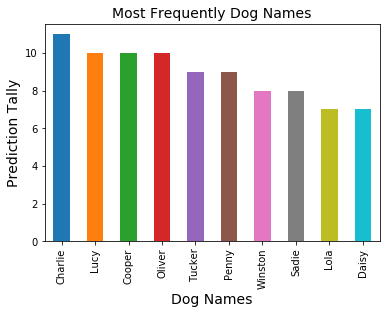

```python
# Top Dog Names
freq_names.plot(kind='bar')
plt.xlabel("Dog Names",fontsize = 14);
plt.ylabel("Prediction Tally",fontsize = 14);
plt.title("Most Frequently Dog Names",fontsize = 14);
```

## 3 - Insight

### The Dog with the highest favorite count is a Lakeland Terrier in the "Puppo" dog stage

```python
# Top Favorite tweet and the Photo along with it!
# It goes to a dog in the "Puppo" dog stage
top_fav_tweet = df.sort_values('favorite_count',ascending=False);
top_fav_tweet = top_fav_tweet[['tweet_id','favorite_count','jpg_url','dog_stage','Prediction1']]
top_fav_tweet.head()
```

|  | tweet_id | favorite_count | jpg_url | dog_stage | Prediction1 |
| --- | --- | --- | --- | --- | --- |
| 1571 | 822872901745569793 | 132810 | https://pbs.twimg.com/media/C2tugXLXgAArJO4.jpg | puppo | Lakeland_terrier |
| 1122 | 744234799360020481 | 131075 | https://pbs.twimg.com/ext_tw_video_thumb/74423... | doggo | Labrador_retriever |
| 1816 | 879415818425184262 | 107956 | https://pbs.twimg.com/ext_tw_video_thumb/87941... | NaN | English_springer |
| 1480 | 807106840509214720 | 107015 | https://pbs.twimg.com/ext_tw_video_thumb/80710... | NaN | Chihuahua |
| 1766 | 866450705531457537 | 106827 | https://pbs.twimg.com/media/DAZAUfBXcAAG_Nn.jpg | pupper | French_bulldog |

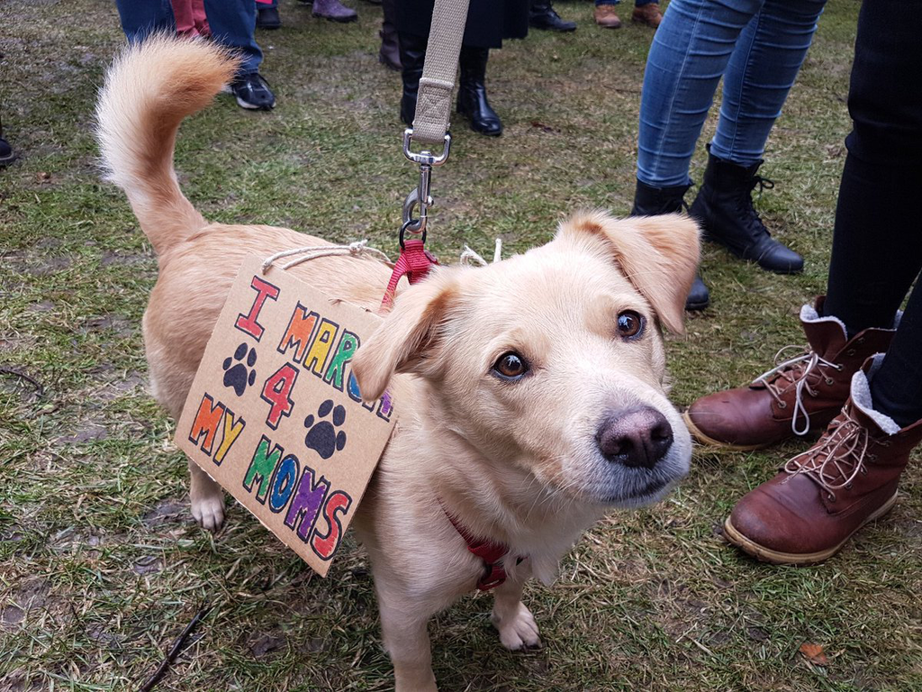

```python
# Here's the photo for the proof
url = df.jpg_url[1571]
r = requests.get(url)
Image.open(BytesIO(r.content))
```